# EN Collinear

Kevin Wang

28/09/2019

# 1 Generate data

```r
library(tidyverse)
library(mvtnorm)
library(glmnet)
library(directlabels)


n = 1000
set.seed(1234)
a = rnorm(n)
b = rnorm(n)
c = rnorm(n)

x1 = a-b
x2 = b-c
x3 = a-c

cor(cbind(x1, x2, x3))
```

```
##            x1         x2        x3
## x1  1.0000000 -0.4912927 0.4640289
## x2 -0.4912927  1.0000000 0.5435705
## x3  0.4640289  0.5435705 1.0000000
```

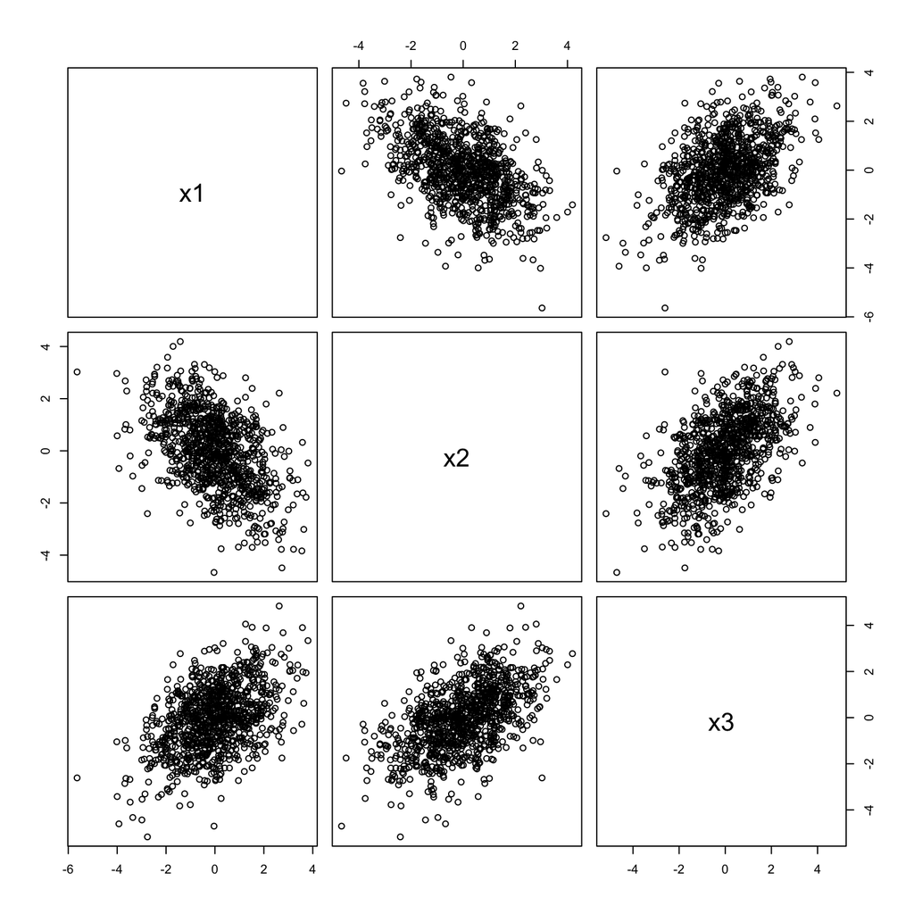

```r
pairs(cbind(x1, x2, x3))
```

```r
e = rnorm(n)

## y equals to x1 multiple by coef of 1 plus some noise
y = (x1) + e
```

# 2 Regression with the only data generating variable

```r
## Least squares
summary(lm(y ~ x1))
```

```
##
## Call:
## lm(formula = y ~ x1)
##
## Residuals:
##      Min       1Q   Median       3Q      Max
## -3.03386 -0.68222  0.01749  0.66867  3.13337
##
## Coefficients:
##              Estimate Std. Error t value Pr(>|t|)
## (Intercept) -0.009679   0.031455  -0.308    0.758
## x1           0.998336   0.023149  43.127   <2e-16 ***
## ---
## Signif. codes:  0 '***' 0.001 '**' 0.01 '*' 0.05 '.' 0.1 ' ' 1
##
## Residual standard error: 0.9943 on 998 degrees of freedom
## Multiple R-squared:  0.6508, Adjusted R-squared:  0.6504
## F-statistic:  1860 on 1 and 998 DF,  p-value: < 2.2e-16
```

```r
## Lasso regression
lasso_x1 = glmnet::cv.glmnet(
  x = cbind(Int = 1, x1),
  y = y, alpha = 1, intercept = FALSE)

coef(lasso_x1)
```

```
## 3 x 1 sparse Matrix of class "dgCMatrix"
##                     1
## (Intercept) .
## Int         .
## x1          0.8810406
```

```r
## Ridge regression
glmnet_x1 = glmnet::cv.glmnet(
  x = cbind(Int = 1, x1),
  y = y, alpha = 0, intercept = FALSE)

coef(glmnet_x1)
```

```
## 3 x 1 sparse Matrix of class "dgCMatrix"
##                     1
## (Intercept) .
## Int         .
## x1          0.8154616
```

As expected, nothing goes wrong with this type of regression.

# 3 Introducing perfect collinearity to least squares

- When both `x1` and `x2` are included, then `x2` is considered to be non-significant, as expected.
- When `x1`, `x2` and `x3` are included, then `x3` is not identifix1le using least squares regression, as expected. In `R`, this is shown as NA.

```r
summary(lm(y ~ x1 + x2))
```

```
##
## Call:
## lm(formula = y ~ x1 + x2)
##
## Residuals:
##      Min       1Q   Median       3Q      Max
## -3.03166 -0.68462  0.01243  0.66786  3.13330
##
## Coefficients:
##              Estimate Std. Error t value Pr(>|t|)
## (Intercept) -0.009515   0.031484  -0.302    0.763
## x1           1.000719   0.026590  37.635   <2e-16 ***
## x2           0.004597   0.025196   0.182    0.855
## ---
## Signif. codes:  0 '***' 0.001 '**' 0.01 '*' 0.05 '.' 0.1 ' ' 1
##
## Residual standard error: 0.9947 on 997 degrees of freedom
## Multiple R-squared:  0.6508, Adjusted R-squared:  0.6501
## F-statistic: 929.1 on 2 and 997 DF,  p-value: < 2.2e-16
```

```r
summary(lm(y ~ x1 + x2 + x3))
```

```
##
## Call:
## lm(formula = y ~ x1 + x2 + x3)
##
## Residuals:
##      Min       1Q   Median       3Q      Max
## -3.03166 -0.68462  0.01243  0.66786  3.13330
##
## Coefficients: (1 not defined because of singularities)
##              Estimate Std. Error t value Pr(>|t|)
## (Intercept) -0.009515   0.031484  -0.302    0.763
## x1           1.000719   0.026590  37.635   <2e-16 ***
## x2           0.004597   0.025196   0.182    0.855
## x3                 NA         NA      NA       NA
## ---
## Signif. codes:  0 '***' 0.001 '**' 0.01 '*' 0.05 '.' 0.1 ' ' 1
##
## Residual standard error: 0.9947 on 997 degrees of freedom
## Multiple R-squared:  0.6508, Adjusted R-squared:  0.6501
## F-statistic: 929.1 on 2 and 997 DF,  p-value: < 2.2e-16
```

# 4 Introducing perfect collinearity to Lasso

Lasso still picks the only variable. Which is re-assuring in some sense? Because it went for the most parsimonious model with `x1`, not the model with `x3` minus `x2`.

```r
lasso_all_three = glmnet::cv.glmnet(
  x = cbind(x1, x2, x3),
  y = y, alpha = 1)

coef(lasso_all_three)
```

```
## 4 x 1 sparse Matrix of class "dgCMatrix"
##                       1
## (Intercept) -0.01549597
## x1           0.85682426
## x2           .
## x3           .
```

But if we do leave out the the true variable `x1`, then the coefficient values of `x2` and `x3` are almost identical in magnitude as that of `x1` but in opposite signs. This is kinda expected.

```r
lasso_only_two = glmnet::cv.glmnet(
  x = cbind(x2, x3),
  y = y, alpha = 1)

coef(lasso_only_two)
```

```
## 3 x 1 sparse Matrix of class "dgCMatrix"
##                      1
## (Intercept) -0.0161261
## x2          -0.8388879
## x3           0.8408169
```

# 5 Introducing perfect collinearity to Ridge

```r
ridge_all_three = glmnet::cv.glmnet(
  x = cbind(x1, x2, x3),
  y = y, alpha = 0)

coef(ridge_all_three)
```

```
## 4 x 1 sparse Matrix of class "dgCMatrix"
##                       1
## (Intercept) -0.01654338
## x1           0.56970635
## x2          -0.25865259
## x3           0.26086095
```

```r
sum(coef(ridge_all_three))
```

```
## [1] 0.5553713
```

```r
sum(coef(ridge_all_three))/2*3 ## Mathematically seems to be doing the same job as only regressing upon x1.
```

```
## [1] 0.833057
```

Fitting x2 and x3 has similar result as the Lasso.

```r
ridge_only_two = glmnet::cv.glmnet(
  x = cbind(x2, x3),
  y = y, alpha = 0)

coef(ridge_only_two)
```

```
## 3 x 1 sparse Matrix of class "dgCMatrix"
##                       1
## (Intercept) -0.01494608
## x2          -0.86624887
## x3           0.86917417
```

```r
sum(coef(ridge_only_two))
```

```
## [1] -0.01202078
```

# 6 Discussion

In between step 1 and step 2 of CPOP, it might be better to run a Lasso to eliminate the highly collinear features? Perhaps this will further improve on the stability of estimation.

# 7 Extensions will a general Elastic net model perform the same thing as Lasso in Section Collinear Lasso

Answer: only if alpha is large enough.

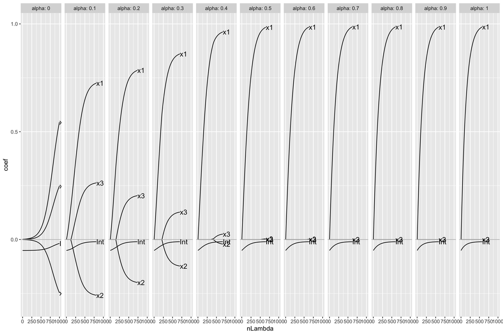